# One Sample Hypothesis Testing for $\mu$

Arnab Aich

## Introduction

Hypothesis testing is a critical statistical tool used to make inferences about population parameters using sample data. In particular, one-sample hypothesis testing allows us to test claims about the population mean ($\mu$) based on a sample from that population. The process involves comparing the sample mean to a hypothesized value under the assumption that the null hypothesis is true.

Hypothesis testing involves the following key steps:

1. Formulating the null and alternative hypotheses.
2. Choosing a significance level ($\alpha$).
3. Calculating the appropriate test statistic.
4. Determining the p-value or comparing the test statistic to critical values.
5. Making a decision to reject or fail to reject the null hypothesis.

## Key Terms and Definitions

Before we delve into the details of one-sample hypothesis testing, let’s review some key terms and definitions that are essential for understanding the process.

### Null Hypothesis ($H_0$)

The null hypothesis is the default assumption or claim that there is no effect or no difference. In hypothesis testing for the population mean, it often states that the mean equals a specific value.
$$H_0: \mu = \mu_0$$
where $\mu_0$ is the hypothesized population mean. Null Hypothesis is set under plausible reaction.

**Example:** A pharmaceutical company claims that a new drug does not change blood pressure. The null hypothesis can be written as:
$$H_0: \text{The drug has no effect on blood pressure (mean change = 0)}$$
In other words, if we test this hypothesis, we assume there is no effect until we have evidence to prove otherwise.

### Alternative Hypothesis ($H_A$)

The alternative hypothesis is what we aim to provide evidence for; it suggests that there is a significant effect or difference. For one-sample hypothesis testing of the population mean, it takes one of the following forms:

- Two-tailed: $H_A: \mu \neq \mu_0$
- Right-tailed: $H_A: \mu > \mu_0$
- Left-tailed: $H_A: \mu < \mu_0$

**Example:** The alternative hypothesis states that the drug does affect blood pressure. We can write this as:

$$H_A: \text{The drug has an effect on blood pressure (mean change ≠ 0)}$$

If our test results show significant evidence, we can reject the null hypothesis in favor of the alternative hypothesis.

### Type I Error

A Type I error occurs when the null hypothesis is rejected but it is actually true. It represents a false positive result. Probability of Type I error is denoted by $\alpha$.

**Example:** Suppose the drug does not actually affect blood pressure (the null hypothesis is true), but our test incorrectly concludes that it does. This mistake is a Type I error.

### Type II Error

A Type II error occurs when the null hypothesis is not rejected when the alternative hypothesis is true. It represents a false negative result. Probability of Type II error is denoted by $\beta$.

**Example:** If the drug actually affects blood pressure (the alternative hypothesis is true), but our test incorrectly concludes that it does not, we have made a Type II error.

### Significance Level ($\alpha$)

The probability of making a Type I error is called the **significance level** ($\alpha$, it is the threshold we set for rejecting the null hypothesis.

**Example:** If we set $\alpha = 0.05$, it means we are willing to accept a 5% chance of making a Type I error. In other words, we will reject the null hypothesis if the p-value is less than 0.05.

### Power of a Test

The power of a hypothesis test is the probability of correctly rejecting the null hypothesis when it is false (i.e., rejecting $H_0$ when $H_A$ is true). It is calculated as:

$$\text{Power} = 1 - \beta$$

**Example:** If the power of our test is 0.90 (90%), it means there is a 90% chance that we will correctly detect the effect of the drug on blood pressure if it truly exists.

### Test Statistic

The **test statistic** is a standardized value calculated from sample data that is compared against the critical value to decide whether to reject the null hypothesis. It measures how far the sample statistic is from the null hypothesis value, under the assumption that the null hypothesis is true.

**Example:** Suppose we are testing whether the mean blood pressure change is zero. The test statistic could be calculated using:
$$Z_{stat} = \frac{\bar{X} - \mu_0}{\frac{\sigma}{\sqrt{n}}}$$
where:

- $\bar{X}$ is the sample mean,
- $\mu_0$ is the mean under the null hypothesis,
- $\sigma$ is the population standard deviation, and
- $n$ is the sample size.

### p-value

The p-value is the probability of obtaining test results at least as extreme as the results observed, under the assumption that the null hypothesis is true. It helps us quantify the evidence against the null hypothesis.

- **If the p-value is less than or equal to $\alpha$**, we reject the null hypothesis.
- **If the p-value is greater than $\alpha$**, we fail to reject the null hypothesis.

**Example:** Suppose a p-value of 0.03 is calculated from a test. This means there is a 3% chance of obtaining the observed result, or something more extreme, if the null hypothesis is true. If the p-value is less than the significance level ($\alpha = 0.05$), we reject the null hypothesis.

### Critical Value

The critical value is the cutoff point that defines the rejection region of the hypothesis test. It depends on the chosen significance level $\alpha$ and the type of test (two-tailed, right-tailed, or left-tailed).

**Example:** In a two-tailed test with $\alpha = 0.05$, the critical values could be -1.96 and 1.96 (for a standard normal distribution). If the test statistic falls outside this range (less than -1.96 or greater than 1.96), we reject the null hypothesis.

### Summary

Here is a quick summary:

| Concept | Definition | Example |
| --- | --- | --- |
| Null Hypothesis | Assumes no effect or no difference. | The drug does not change blood pressure. |
| Alternative Hypothesis | Assumes there is an effect or a difference. | The drug changes blood pressure. |
| Type I Error | Rejecting $H_0$ when it is true (false positive). | Concluding the drug works when it doesn’t. |
| Type II Error | Failing to reject $H_0$ when $H_A$ is true (false negative). | Concluding the drug does not work when it actually does. |
| Power | Probability of correctly rejecting $H_0$ when $H_A$ is true. | 90% chance of detecting an effect of the drug if it exists. |
| Significance Level | Threshold ($\alpha$) for deciding to reject $H_0$. | Common values are 0.05, 0.01, or 0.10. |
| Test Statistic | Standardized value used to compare against critical values to make a decision. | A t-value from a t-test comparing sample mean and hypothesized mean. |
| Critical Value | Boundary value that defines the rejection region for $H_0$. | Reject $H_0$ if the test statistic is outside -1.96 or 1.96. |
| p-value | Probability of observing the data, or something more extreme, if $H_0$ is true. | p-value < 0.05 leads to rejecting $H_0$. |

## Z-Test ($\sigma$ Known)

The Z-test is a hypothesis test used to compare the population mean to a hypothesized value, based on a sample from the population. It is commonly used when the population standard deviation is known. The test statistic follows a standard normal distribution under the null hypothesis.

### Assumptions

1. The data is a simple random sample from the population.
2. The population from which the sample is drawn is normally distributed or the sample size is sufficiently large (by the Central Limit Theorem).
3. The population standard deviation $\sigma$ is known .

### Step 1: Hypotheses

- **Null Hypothesis ($H_0$):**  
  $H_0: \mu = \mu_0$  
  The population mean is equal to the hypothesized mean $\mu_0$.
- **Alternative Hypothesis ($H_A$):**  
  The alternative hypothesis depends on the test type:
  - **Right-tailed test:** $H_A: \mu > \mu_0$  
    The population mean is greater than the hypothesized mean.
  - **Left-tailed test:** $H_A: \mu < \mu_0$  
    The population mean is less than the hypothesized mean.
  - **Two-tailed test:** $H_A: \mu \neq \mu_0$  
    The population mean is different from the hypothesized mean.

### Step 2: Test Statistic

To test the hypotheses, the Z-statistic is calculated using the formula:
$$Z_{\text{stat}} = \frac{\sqrt{n}(\bar{X} - \mu_0)}{\sigma}$$
where:

- $\bar{X}$ is the sample mean,
- $\mu_0$ is the hypothesized population mean,
- $\sigma$ is the population standard deviation,
- $n$ is the sample size.

### Step 3: Distribution of Test Statistic

Under the null hypothesis, the test statistic follows a standard normal distribution (Z-distribution) with a mean of 0 and a standard deviation of 1:
$$Z_{\text{stat}} \sim N(0, 1)$$

### Step 4: Critical Value

The critical value is determined by the significance level $\alpha(= 0.05)$ and the type of test (one-tailed or two-tailed):

- For a **right-tailed test**, the critical value $Z_{\alpha}$ corresponds to the area under the normal curve to the right of $Z_{\alpha}$. The critical value is $Z_{0.05} = 1.645$.
- For a **left-tailed test**, the critical value $Z_{\alpha}$ corresponds to the area under the normal curve to the left of $Z_{\alpha}$. The critical value is $Z_{0.05} = -1.645$.
- For a **two-tailed test**, the critical values correspond to the areas in both tails of the distribution (i.e., $\alpha/2$ in each tail). The critical values are $\pm Z_{0.025} = \pm 1.96$.

### Step 5: p-value Calculation

Once the test statistic is computed-$Z_{observed}$, the p-value is calculated based on the type of test:

- **Right-tailed test:**
  The p-value is the probability of obtaining a test statistic greater than the observed $Z{\text{stat}})$-value:
  $$p-value = P_{H_0}(Z > Z_{\text{observed}})$$
- **Left-tailed test:**
  The p-value is the probability of obtaining a test statistic less than the observed $Z{\text{stat}})$-value:
  $$p-value = P_{H_0}(Z < Z_{\text{observed}})$$
- **Two-tailed test:**
  The p-value is the probability of obtaining a test statistic as extreme as the observed $Z{\text{stat}})$-value in either direction:
  $$p-value = 2 \times P_{H_0}(Z > |Z_{\text{observed}}|)$$

where $Z \sim N(0, 1)$.

### Step 6: Conclusion

- **If the p-value is less than or equal to the significance level $\alpha$ or $Z_{observed}$ falls in the critical region:**  
  Reject the null hypothesis $H_0$. There is sufficient evidence to support the alternative hypothesis $H_A$.
- **If the p-value is greater than $\alpha$ or $Z_{observed}$ falls outside the critical region:**  
  Fail to reject the null hypothesis $H_0$. There is insufficient evidence to support the alternative hypothesis.

#### Example

Suppose we are testing whether the average height of a population is 170 cm. A sample of 50 individuals has a mean height of 172 cm, and the population standard deviation is 6 cm. Let’s perform a two-tailed test at $\alpha = 0.05$.

- **Step 1: Hypotheses:**
  - $H_0: \mu = 170$
  - $H_A: \mu \neq 170$
- **Step 2: Test Statistic:**
  $$Z = \frac{\sqrt{50} (172 - 170)}{6} = \frac{2 \times 7.071}{6} \approx
  2.36$$
- **Step 3: Distribution under $H_0$:**
  $$Z_{\text{stat}} \sim N(0,
  1)$$
- **Step 4: Critical Values:**  
  For a two-tailed test at $\alpha = 0.05$, the critical values are $Z = \pm 1.96$.
- **Step 5: p-value Calculation:**
  $$p = 2 \times P(Z > 2.36) = 2 \times 0.0091 = 0.0182$$
- **Step 6: Conclusion:**

Since $p = 0.0182 < 0.05$, we reject $H_0$. There is sufficient evidence to conclude that the population mean height is different from 170 cm(The test statistic falls in the critical region).

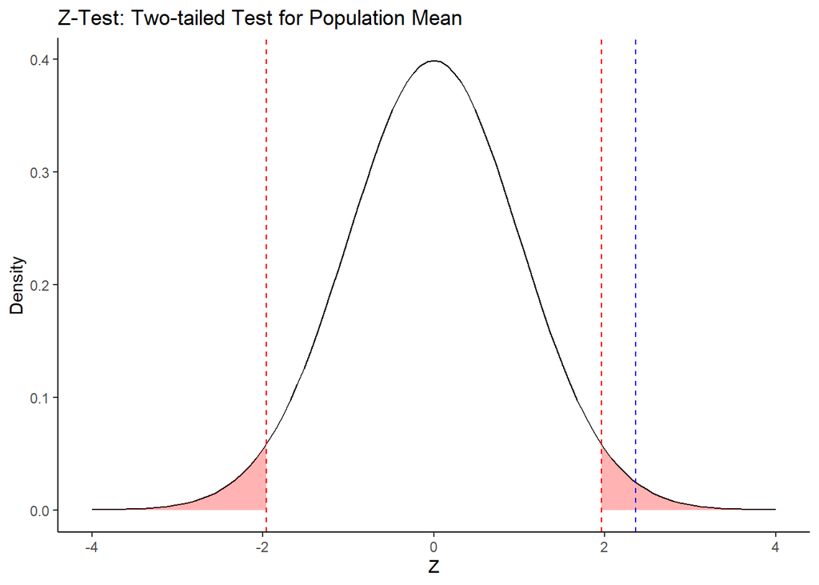

- **Black Line:** Represents the normal curve.
- **Red Shaded Region:** Indicates the critical region where the null hypothesis would be rejected.
- The critical region is on both side.
- **Red Dashed Lines:** Represent the critical values corresponding to the significance level ($\alpha$).
- **Blue Dashed Line:** Represents the test statistic value calculated from the data.

## t-Test ($\sigma$ Unknown)

The t-test is a hypothesis test used to compare the population mean to a hypothesized value, based on a sample from the population. It is commonly used when the population standard deviation is unknown and must be estimated from the sample data. The test statistic follows a t-distribution under the null hypothesis.

### Assumptions

1. The data is a simple random sample from the population.
2. The population from which the sample is drawn is normally distributed or the sample size is sufficiently large (by the Central Limit Theorem).
3. The population standard deviation $\sigma$ is not known (it will be estimated by sample sd $S$).

### Step 1: Hypotheses

- **Null Hypothesis ($H_0$):**  
  $H_0: \mu = \mu_0$  
  The population mean is equal to the hypothesized mean $\mu_0$.
- **Alternative Hypothesis ($H_A$):**  
  The alternative hypothesis depends on the test type:
  - **Right-tailed test:** $H_A: \mu > \mu_0$  
    The population mean is greater than the hypothesized mean.

### Step 2: Test Statistic

Since the population standard deviation $\sigma$ is unknown, we use the t-statistic:
$$t_{\text{stat}} = \frac{\bar{X} - \mu_0}{\frac{s}{\sqrt{n}}}$$
where:

- $\bar{X}$ is the sample mean,
- $\mu_0$ is the hypothesized population mean,
- $s$ is the sample standard deviation,
- $n$ is the sample size.

### Step 3: Distribution of Test Statistic

Under the null hypothesis, the test statistic follows a t-distribution with $n - 1$ degrees of freedom:
$$t_{\text{stat}} \sim t_{n-1}$$

### Step 4: Critical Value

The critical value is determined by the significance level $\alpha$ and the type of test (right-tailed in this case):

- For a **right-tailed test**, the critical value $t_{\alpha, n-1}$ corresponds to the area to the right of the critical t-value in the t-distribution.

For example, if $\alpha = 0.05$ and $n = 20$ (so degrees of freedom = 19), the critical value is:
$$t_{0.05, 19} \approx 1.729$$

### Step 5: p-value Calculation

Once the test statistic is computed, the p-value is calculated as:
$$p-value = P_{H_0}(t_{n-1} > t_{\text{observed}}))$$
where $t_{\text{stat}}$ is the computed test statistic, and the p-value is determined using the t-distribution with $n - 1$ degrees of freedom.

### Step 6: Conclusion

- **If the p-value is less than or equal to the significance level $\alpha$:**  
  Reject the null hypothesis $H_0$. There is sufficient evidence to support the alternative hypothesis $H_A$.
- **If the p-value is greater than $\alpha$:**  
  Fail to reject the null hypothesis $H_0$. There is insufficient evidence to support the alternative hypothesis.

#### Example:

Suppose we are testing whether the average IQ of a group of students is greater than 100. A sample of 25 students has a mean IQ of 104 with a sample standard deviation of 10. Let’s perform a right-tailed t-test at $\alpha = 0.05$.

- **Step 1: Hypotheses:**
  - $H_0: \mu = 100$
  - $H_A: \mu > 100$ (right-tailed test)
- **Step 2: Test Statistic:**
  $$t_{observed} = \frac{104 - 100}{\frac{10}{\sqrt{25}}} = \frac{4}{2} =
  2.0$$
- **Step 3: Distribution under $H_0$:**  
  $t \sim t_{24}$ (since $n - 1 = 25 - 1 = 24$)
- **Step 4: Critical Value:**
  For a right-tailed test with $\alpha = 0.05$ and 24 degrees of freedom, the critical value is approximately:
  $$t_{0.05, 24} \approx 1.711$$
  Since $t_{observed} = 2.0$ exceeds the critical value, this suggests rejection of the null hypothesis.
- **Step 5: p-value Calculation:** Using the t-distribution table or a calculator, the p-value is:
  $$p = P(t_{24} > 2.0) \approx 0.029$$
- **Step 6: Conclusion:** Since $p = 0.029 < 0.05$, we reject $H_0$. There is sufficient evidence to conclude that the average IQ of the group of students is greater than 100.

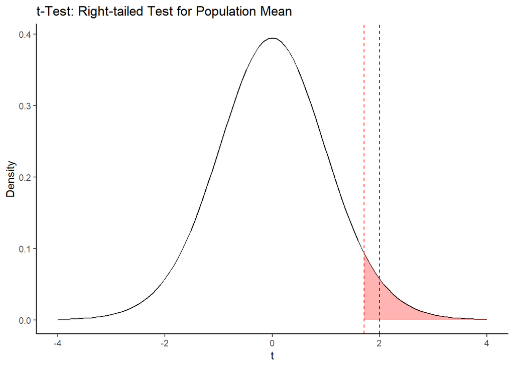

- **Black Line:** Represents the t-distribution curve.
- **Red Shaded Region:** Indicates the critical region where the null hypothesis would be rejected.
- the critical region is on the right side only.
- **Red Dashed Lines:** Represent the critical values corresponding to the significance level ($\alpha$).
- **Blue Dashed Line:** Represents the test statistic value calculated from the data.

## Two-Tailed Test and Confidence Interval

A two-tailed hypothesis test for the mean and a confidence interval (CI) are closely related methods for assessing whether there is evidence to reject a null hypothesis. Both approaches often lead to the same conclusion because they are based on the same underlying statistical principles.

- **Two-Tailed Test**: In a two-tailed hypothesis test, we check whether the population mean is significantly different from a specific value (the null hypothesis). We reject the null hypothesis if the sample mean is significantly higher or lower than this value, based on a chosen significance level (e.g., $\alpha = 0.05$).
- **Confidence Interval**: A confidence interval provides a range of plausible values for the population mean. For instance, a 95% confidence interval indicates that we are 95% confident the true mean lies within this range.

### Why Do They Lead to the Same Conclusion?

The reason a two-tailed hypothesis test and a confidence interval often lead to the same conclusion is that they are both based on the concept of sampling variability and the same distribution (usually the t-distribution or normal distribution):

- **Confidence Interval Perspective**: A 95% confidence interval is constructed in a way that, if we repeatedly sampled from the population, 95% of those intervals would contain the true mean. If the hypothesized mean falls outside of this interval, it suggests that the observed sample mean is too extreme to be consistent with the null hypothesis.
- **Hypothesis Testing Perspective**: In a two-tailed test, we determine whether the observed sample mean is significantly different from the hypothesized mean by calculating a test statistic. If this test statistic is extreme enough (based on the same threshold as the confidence interval), it leads to rejecting the null hypothesis.

Because both methods rely on the same sampling distribution, they use the same logic to determine what counts as “significant” or “extreme” results. This is why, if a value is not in the confidence interval, it corresponds to rejecting the null hypothesis in a two-tailed test.

### Example

In essence, both approaches are different ways of answering the same question: “Is the observed sample mean likely to have come from a population with the hypothesized mean?”

## Recap

In this document, we have covered the following concepts:

1. **One-Sample Hypothesis Testing**: We discussed how to perform hypothesis tests on the population mean ($\mu$) using sample data, including both Z-tests (when the population standard deviation is known) and t-tests (when the population standard deviation is unknown).
2. **Null Hypothesis ($H_0$)**: The null hypothesis represents the claim we test, often that the population mean equals a specific value ($\mu_0$). For example, $H_0: \mu = \mu_0$.
3. **Alternative Hypothesis ($H_A$)**: The alternative hypothesis is the claim we aim to support, which opposes the null hypothesis. It can be two-tailed ($\mu \neq \mu_0$), right-tailed ($\mu > \mu_0$), or left-tailed ($\mu < \mu_0$).
4. **Test Statistics**: We learned how to compute the Z-statistic when the population standard deviation ($\sigma$) is known and the t-statistic when $\sigma$ is unknown.
5. **p-value and Critical Values**: The p-value helps determine the significance of the results by comparing the test statistic to a threshold defined by the significance level ($\alpha$). We also explored how to compare the test statistic to critical values.
6. **Decision Making**: Based on the p-value or critical value approach, we either reject or fail to reject the null hypothesis.

## Q&A Section

Below are ten key questions and answers related to one-sample hypothesis testing for the population mean ($\mu$):

#### 1. What is the purpose of hypothesis testing?

**Answer:** Hypothesis testing is used to make decisions about a population parameter based on sample data, by testing a null hypothesis against an alternative hypothesis.

#### 2. What are the null and alternative hypotheses in one-sample hypothesis testing?

**Answer:**

- The **null hypothesis** ($H_0$) asserts that the population mean equals a specific value ($\mu_0$).
- The **alternative hypothesis** ($H_A$) suggests that the population mean is different from ($\mu_0$).

#### 3. What is a p-value?

**Answer:** A p-value is the probability of observing a test statistic as extreme as, or more extreme than, the observed value, assuming the null hypothesis is true.

#### 4. When do you reject the null hypothesis?

**Answer:** The null hypothesis is rejected if the p-value is less than or equal to the significance level ($\alpha$), or if the test statistic falls in the critical region.

#### 5. What is the difference between a one-tailed and two-tailed test?

**Answer:**

- A **one-tailed test** checks whether the population mean is either greater than or less than the hypothesized value.
- A **two-tailed test** checks whether the population mean is different (either greater or less) than the hypothesized value.

#### 6. What is a Type I error?

**Answer:** A Type I error occurs when we incorrectly reject the null hypothesis when it is true (false positive).

#### 7. What is a Type II error?

**Answer:** A Type II error occurs when we fail to reject the null hypothesis when it is false (false negative).

#### 8. What is the test statistic in a Z-test?

**Answer:** The test statistic in a Z-test is:
$$Z_{stat} = \frac{\sqrt{n}(\bar{X} - \mu_0)}{\sigma}$$
where $\bar{X}$ is the sample mean, $\mu_0$ is the hypothesized mean, $\sigma$ is the population standard deviation, and $n$ is the sample size.

#### 9. When do you use a t-test instead of a Z-test?

**Answer:** A t-test is used when the population standard deviation is unknown, and we rely on the sample standard deviation to estimate it.

#### 10. What is the critical value?

**Answer:** A critical value is a point on the test statistic distribution that defines the boundary of the rejection region. If the test statistic exceeds the critical value, the null hypothesis is rejected.